# hw6

Mike Lehman

October 11, 2016

## #1

```r
library(ggplot2)
library(effects)
data(diamonds)

price_df <- as.data.frame(diamonds[,"price"])
colnames(price_df) <- c("price")
summary(price_df$price)
```

```
##    Min. 1st Qu.  Median    Mean 3rd Qu.    Max.
##     326     950    2401    3933    5324   18820
```

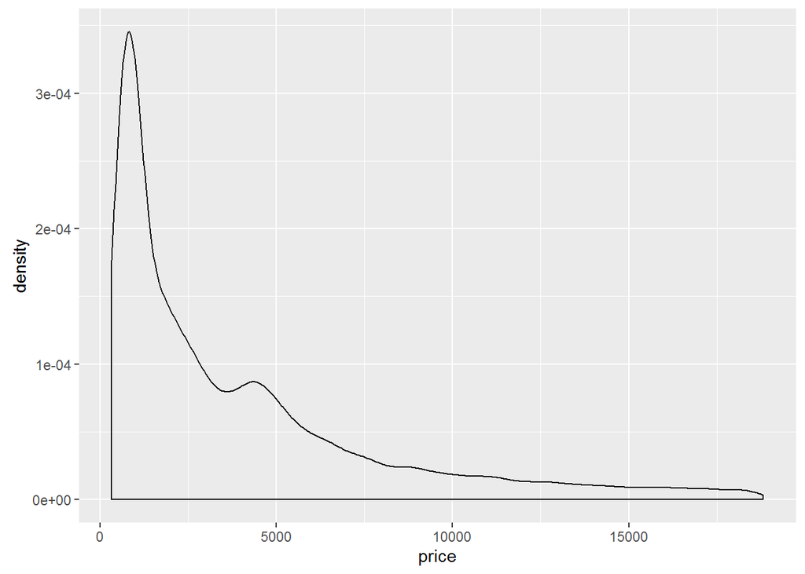

```r
d <- ggplot(price_df["price"], aes(x = price))
d + geom_density()
```

## #2

```r
d_log10 <- ggplot(price_df["price"], aes(x = log(price, base = 10)))
summary(log(price_df$price, base = 10))
```

```
##    Min. 1st Qu.  Median    Mean 3rd Qu.    Max.
##   2.513   2.978   3.380   3.382   3.726   4.275
```

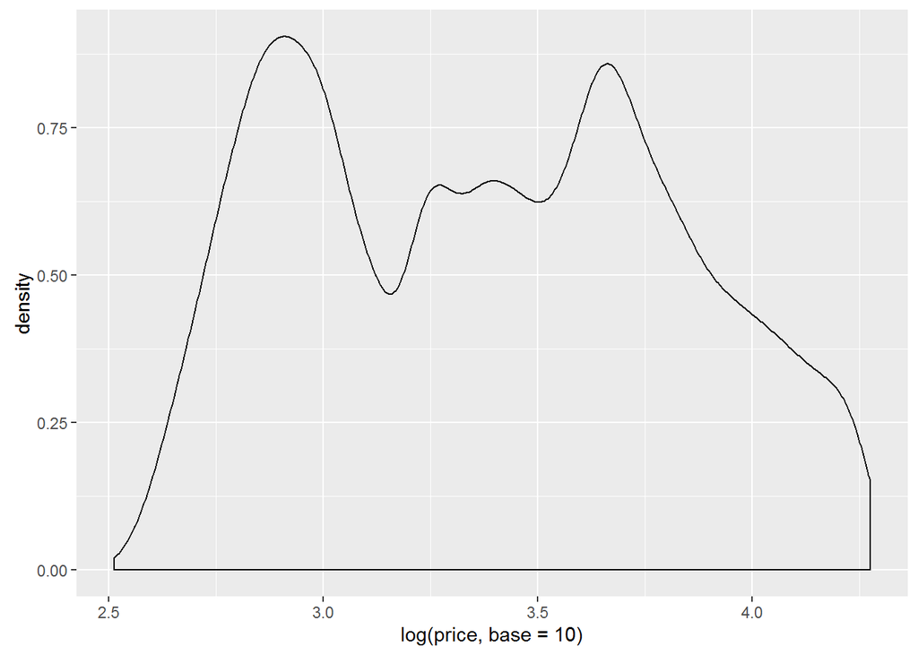

```r
d_log10 + geom_density()
```

Performing a log (base 10) transformation on the price variable was worthwhile in this case because it reduced the scope of the varialbe’s distribution and brought the mean and median much closer than they were in the raw data.

Since the range of the raw data for the price variable was so wide and all values were positive, a log transformation was worthwhile.

## #3

```r
set.seed(123)
train_sample <- sample(53940, 26970)

diamonds_train <- diamonds[train_sample, ]
diamonds_test  <- diamonds[-train_sample, ]

str(diamonds_train)
```

```
## Classes 'tbl_df', 'tbl' and 'data.frame':    26970 obs. of  10 variables:
##  $ carat  : num  1.03 0.5 1.74 0.51 0.7 0.71 0.32 0.9 0.32 1.52 ...
##  $ cut    : Ord.factor w/ 5 levels "Fair"<"Good"<..: 4 1 3 5 5 5 3 1 5 4 ...
##  $ color  : Ord.factor w/ 7 levels "D"<"E"<"F"<"G"<..: 4 1 5 1 5 5 2 4 4 4 ...
##  $ clarity: Ord.factor w/ 8 levels "I1"<"SI2"<"SI1"<..: 4 3 2 4 3 8 3 1 6 4 ...
##  $ depth  : num  62.3 65.7 62.1 61.2 62.5 62 63.3 65.1 61.6 62.6 ...
##  $ table  : num  59 56 59 55 56 54 55 58 56 55 ...
##  $ price  : int  6214 1323 10086 1882 2294 3190 672 1939 708 12958 ...
##  $ x      : num  6.38 5.01 7.65 5.18 5.64 5.71 4.36 6.05 4.42 7.39 ...
##  $ y      : num  6.42 4.97 7.78 5.16 5.69 5.75 4.33 5.99 4.44 7.28 ...
##  $ z      : num  3.99 3.28 4.79 3.16 3.54 3.55 2.75 3.92 2.73 4.59 ...
```

```r
str(diamonds_test)
```

```
## Classes 'tbl_df', 'tbl' and 'data.frame':    26970 obs. of  10 variables:
##  $ carat  : num  0.21 0.24 0.22 0.3 0.2 0.32 0.3 0.3 0.23 0.23 ...
##  $ cut    : Ord.factor w/ 5 levels "Fair"<"Good"<..: 4 3 1 2 4 4 2 3 3 3 ...
##  $ color  : Ord.factor w/ 7 levels "D"<"E"<"F"<"G"<..: 2 6 2 7 2 2 7 7 2 5 ...
##  $ clarity: Ord.factor w/ 8 levels "I1"<"SI2"<"SI1"<..: 3 7 4 3 2 1 3 3 4 5 ...
##  $ depth  : num  59.8 62.3 65.1 64 60.2 60.9 63.4 62.7 63.8 61 ...
##  $ table  : num  61 57 61 55 62 58 54 59 55 57 ...
##  $ price  : int  326 336 337 339 345 345 351 351 352 353 ...
##  $ x      : num  3.89 3.95 3.87 4.25 3.79 4.38 4.23 4.21 3.85 3.94 ...
##  $ y      : num  3.84 3.98 3.78 4.28 3.75 4.42 4.29 4.27 3.92 3.96 ...
##  $ z      : num  2.31 2.47 2.49 2.73 2.27 2.68 2.7 2.66 2.48 2.41 ...
```

## #4

```r
price_reg <- lm(price ~ carat + cut + color + clarity, data = diamonds_train)
summary(price_reg)
```

```
##
## Call:
## lm(formula = price ~ carat + cut + color + clarity, data = diamonds_train)
##
## Residuals:
##      Min       1Q   Median       3Q      Max
## -16783.6   -676.0   -199.6    464.9   9734.9
##
## Coefficients:
##              Estimate Std. Error  t value Pr(>|t|)
## (Intercept) -3724.458     19.872 -187.427  < 2e-16 ***
## carat        8894.155     17.143  518.809  < 2e-16 ***
## cut.L         720.433     28.599   25.191  < 2e-16 ***
## cut.Q        -339.831     25.209  -13.481  < 2e-16 ***
## cut.C         175.185     21.832    8.024 1.06e-15 ***
## cut^4          -4.072     17.523   -0.232    0.816
## color.L     -1928.960     25.072  -76.936  < 2e-16 ***
## color.Q      -632.759     22.835  -27.710  < 2e-16 ***
## color.C      -200.682     21.366   -9.393  < 2e-16 ***
## color^4        17.243     19.642    0.878    0.380
## color^5       -91.521     18.592   -4.923 8.59e-07 ***
## color^6       -42.536     16.930   -2.512    0.012 *
## clarity.L    4268.663     43.956   97.112  < 2e-16 ***
## clarity.Q   -1794.710     41.145  -43.619  < 2e-16 ***
## clarity.C     966.876     35.192   27.474  < 2e-16 ***
## clarity^4    -311.778     28.153  -11.075  < 2e-16 ***
## clarity^5     213.314     22.962    9.290  < 2e-16 ***
## clarity^6       6.386     19.977    0.320    0.749
## clarity^7     108.414     17.631    6.149 7.90e-10 ***
## ---
## Signif. codes:  0 '***' 0.001 '**' 0.01 '*' 0.05 '.' 0.1 ' ' 1
##
## Residual standard error: 1162 on 26951 degrees of freedom
## Multiple R-squared:  0.915,  Adjusted R-squared:  0.915
## F-statistic: 1.612e+04 on 18 and 26951 DF,  p-value: < 2.2e-16
```

```r
price_reg_log10 <- lm(log(price, base = 10) ~ carat + cut + color + clarity, data = diamonds_train)
summary(price_reg_log10)
```

```
##
## Call:
## lm(formula = log(price, base = 10) ~ carat + cut + color + clarity,
##     data = diamonds_train)
##
## Residuals:
##      Min       1Q   Median       3Q      Max
## -2.59629 -0.09512  0.02553  0.10781  0.72075
##
## Coefficients:
##               Estimate Std. Error  t value Pr(>|t|)
## (Intercept)  2.5712714  0.0025103 1024.273  < 2e-16 ***
## carat        0.9550545  0.0021657  440.991  < 2e-16 ***
## cut.L        0.0280646  0.0036129    7.768 8.26e-15 ***
## cut.Q       -0.0104373  0.0031846   -3.277  0.00105 **
## cut.C        0.0110580  0.0027580    4.009 6.10e-05 ***
## cut^4        0.0006581  0.0022137    0.297  0.76625
## color.L     -0.2156317  0.0031673  -68.080  < 2e-16 ***
## color.Q     -0.0662756  0.0028847  -22.975  < 2e-16 ***
## color.C      0.0011813  0.0026991    0.438  0.66162
## color^4      0.0203386  0.0024814    8.196 2.58e-16 ***
## color^5     -0.0061295  0.0023487   -2.610  0.00906 **
## color^6      0.0004805  0.0021388    0.225  0.82224
## clarity.L    0.3364601  0.0055529   60.592  < 2e-16 ***
## clarity.Q   -0.1613721  0.0051978  -31.046  < 2e-16 ***
## clarity.C    0.0996837  0.0044458   22.422  < 2e-16 ***
## clarity^4   -0.0288661  0.0035565   -8.116 5.00e-16 ***
## clarity^5    0.0243339  0.0029008    8.389  < 2e-16 ***
## clarity^6   -0.0007686  0.0025237   -0.305  0.76069
## clarity^7    0.0028658  0.0022273    1.287  0.19823
## ---
## Signif. codes:  0 '***' 0.001 '**' 0.01 '*' 0.05 '.' 0.1 ' ' 1
##
## Residual standard error: 0.1468 on 26951 degrees of freedom
## Multiple R-squared:  0.8887, Adjusted R-squared:  0.8886
## F-statistic: 1.196e+04 on 18 and 26951 DF,  p-value: < 2.2e-16
```

## #5

```r
diamonds_test$price_log10 <- log(diamonds_test$price, base = 10)
diamonds_test$PricePrediction <- predict(price_reg, newdata = diamonds_test)
diamonds_test$PricePrediction_log10 <- predict(price_reg_log10, newdata = diamonds_test)
head(diamonds_test)
```

```
##    carat       cut color clarity depth table price    x    y    z
## 2   0.21   Premium     E     SI1  59.8    61   326 3.89 3.84 2.31
## 7   0.24 Very Good     I    VVS1  62.3    57   336 3.95 3.98 2.47
## 9   0.22      Fair     E     VS2  65.1    61   337 3.87 3.78 2.49
## 11  0.30      Good     J     SI1  64.0    55   339 4.25 4.28 2.73
## 15  0.20   Premium     E     SI2  60.2    62   345 3.79 3.75 2.27
## 16  0.32   Premium     E      I1  60.9    58   345 4.38 4.42 2.68
##    price_log10 PricePrediction PricePrediction_log10
## 2     2.513218      -1272.3089              2.839535
## 7     2.526339       -765.5969              2.805364
## 9     2.527630      -1432.2482              2.860746
## 11    2.530200      -2839.7210              2.700325
## 15    2.537819      -2338.2799              2.750487
## 16    2.537819      -3875.1446              2.625297
```

## #6

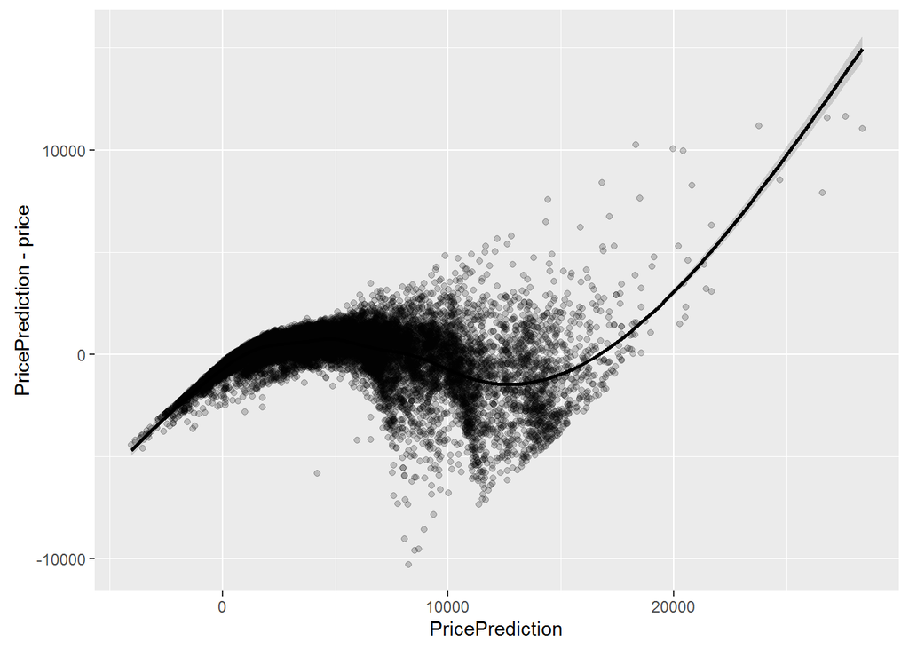

```r
a <- ggplot(data = diamonds_test, aes(x = PricePrediction, y = PricePrediction - price))
a + geom_point(alpha = 0.2, color = "black") + geom_smooth(aes(x = PricePrediction, y = PricePrediction - price), color = "black")
```

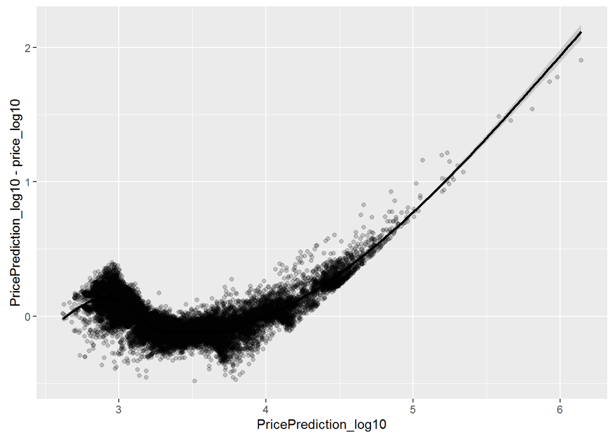

```r
b <- ggplot(data = diamonds_test, aes(x = PricePrediction_log10, y = PricePrediction_log10 - price_log10))
b + geom_point(alpha = 0.2, color = "black") + geom_smooth(aes(x = PricePrediction_log10, y = PricePrediction_log10 - price_log10), color = "black")
```